# Modular Analysis

Chris Alder

25/03/2020

This is a report of the modular analysis on the EKD11 transcriptomics dataset/

I have used the Singhania/O’Garra blood modules, using Qusage to quantify the relative encrihment of the modules.

Qusage will assess the mean expression of all genes in a geneset (module) within a treatment group and compare against a control group, and output the log2Fold Enrichment of for each module.

## Setting directories for Data

This will load the necessarys packages for the analysis, as well as load the module data.

This analysis requires us to have loaded the samples into DESeq2 to identify the genes found to be differentially expressed (DE) in each comparison, as well as for a log transformed normalised count matrix (normalised to library size).

```r
rm(list = ls())

# Libraries
library(DESeq2)
library(ComplexHeatmap)
library(tidyverse)
library(qusage)
library(ggplot2)
library(reshape2)
library(RColorBrewer)
library(scales)

nf.dir      <- "/Users/alderc/1-projects/CAMP/1-AS_timecourse/2-EKD11/1-Pipeline/1-Nextflow/"
work.dir    <- "/Users/alderc/1-projects/1-PIR_project/3-EKD11_AS_Early_TP/"
r.dir       <- paste(work.dir, "1-R/",sep='') #change once refactor is completed
tmp.dir     <- paste(work.dir,"tmp/",sep='')
data.dir    <- paste(work.dir,"4-data/",sep='')
results.dir <- paste(work.dir,"2-results_2020/",sep='')
genome.dir  <- "/Users/alderc/1-projects/9-Data/1-Reference_genomes/1-Mus_musculus/"


module.anno <- read.csv(file=paste(data.dir, '/modular_analysis/Annotation of Blood modules.csv', sep=''),
                        header=TRUE,
                        sep=',');
module.dat <- read.csv(file=paste(data.dir, '/modular_analysis/Blood modules.csv', sep=''),
                       header=TRUE,
                       sep=',');

count.dat <- read.table(file= paste(results.dir, 'genes.vst_counts_with_controls.xls.gz', sep=''),
                       header=TRUE,
                       sep='\t');
# Load DESeq results list
load(paste(r.dir, "Projects/results.Rdata", sep = ""))

deg.list <- lapply(res.list, function(x){
  x <- x[x$DEG, ]
})


#List of Module IDs
module.num <- module.anno$X
print(module.anno[, -2])
```

```
##      X Number.of.genes                             Biological.process
## 1   B1             169                            Ribosome biogenesis
## 2   B2              53                             Ribosome functions
## 3   B3              82         Mitochondria/Oxidative phosphorylation
## 4   B4             732               Myeloid cells/Membrane functions
## 5   B5             144                 Macrophages/Cytokine signaling
## 6   B6             196                 Myeloid cells/Lipid metabolism
## 7   B7             349                     Myeloid cells/Granulocytes
## 8   B8             381       Oxidative phosphorylation/Metabolism/ATP
## 9   B9             408                 Ribosome/Mitochondrial activty
## 10 B10             395                     Cell cycle/DNA replication
## 11 B11             134                             IFN signaling/Il10
## 12 B12             267                      Oxidative phosphorylation
## 13 B13             301 Stress response/Protein folding/Ubiquitination
## 14 B14             172                                  IFN signaling
```

[output cut: 27 more lines]

Transforming data to create Modules into Geneset format for Qusage

```r
module.geneset <- lapply(module.num, function(mod){
  dat <- module.dat[module.dat$Module == mod, 'X'];
  dat <- dat[!is.na(dat)]
  mod <- dat
})

names(module.geneset) <- paste(module.num, module.anno$Biological.process)


#Check to see if Merge was correct
for (mod in names(module.geneset)){
  name <- str_split(mod, " ")[[1]]
  anno <- as.numeric(module.anno[module.anno$X == name[1], 'Number.of.genes']);
  if (length(module.geneset[[mod]]) == anno){
    print(paste("Geneset", mod, 'contains correct number of genes:', anno, sep=' '))
  } else {
    print('Module gene number does not match')
  }
}
```

```
## [1] "Geneset B1 Ribosome biogenesis contains correct number of genes: 169"
## [1] "Geneset B2 Ribosome functions contains correct number of genes: 53"
## [1] "Geneset B3 Mitochondria/Oxidative phosphorylation contains correct number of genes: 82"
## [1] "Geneset B4 Myeloid cells/Membrane functions contains correct number of genes: 732"
## [1] "Geneset B5 Macrophages/Cytokine signaling contains correct number of genes: 144"
## [1] "Geneset B6 Myeloid cells/Lipid metabolism contains correct number of genes: 196"
## [1] "Geneset B7 Myeloid cells/Granulocytes contains correct number of genes: 349"
## [1] "Geneset B8 Oxidative phosphorylation/Metabolism/ATP contains correct number of genes: 381"
## [1] "Geneset B9 Ribosome/Mitochondrial activty contains correct number of genes: 408"
## [1] "Geneset B10 Cell cycle/DNA replication contains correct number of genes: 395"
## [1] "Geneset B11 IFN signaling/Il10 contains correct number of genes: 134"
## [1] "Geneset B12 Oxidative phosphorylation contains correct number of genes: 267"
## [1] "Geneset B13 Stress response/Protein folding/Ubiquitination contains correct number of genes: 301"
## [1] "Geneset B14 IFN signaling contains correct number of genes: 172"
## [1] "Geneset B15 Cytotoxic/T cells/ILC/Tbx21/Eomes contains correct number of genes: 81"
```

[output cut: 26 more lines]

Now we format the rlog data to the format we need

```r
## Trimming data
rownames(count.dat) <- count.dat$gene_id
sample.cols <- grep(pattern = '^naive|d.\\.', x = names(count.dat), value = TRUE)
count.mat <- count.dat[ , sample.cols];
```

## Modular Quantification

For this analysis, I have compared each transmission group separately against the control (i.e MT vs Naive, SBP vs Naive and RTMT vs Naive).

### Overview

Briefly, the script will compare the treatment and control on a individual timepoint (e.g. Day 1), to calculate the fold enrichment of the module, once each module enrichment score is complete it will move onto the next timepoint until all calculations are completed. Qusage will output a log fold enrichment score for each module, as well as p-value for the comparison. Modules with p-value > 0.05 were removed from further analysis.

Finally, the script will look at all the genes within a module, and look to see whether they were DE within the similar comparisons done within DESeq2, and return the proportion of genes within the module that were DE.

```r
# Load Qusage reults (If run already)
if(file.exists(paste(r.dir, "Projects/qusage_results.Rdata", sep = ""))){
  load(paste(r.dir, "Projects/qusage_results.Rdata", sep = ""))
}
```

### MT vs Naive

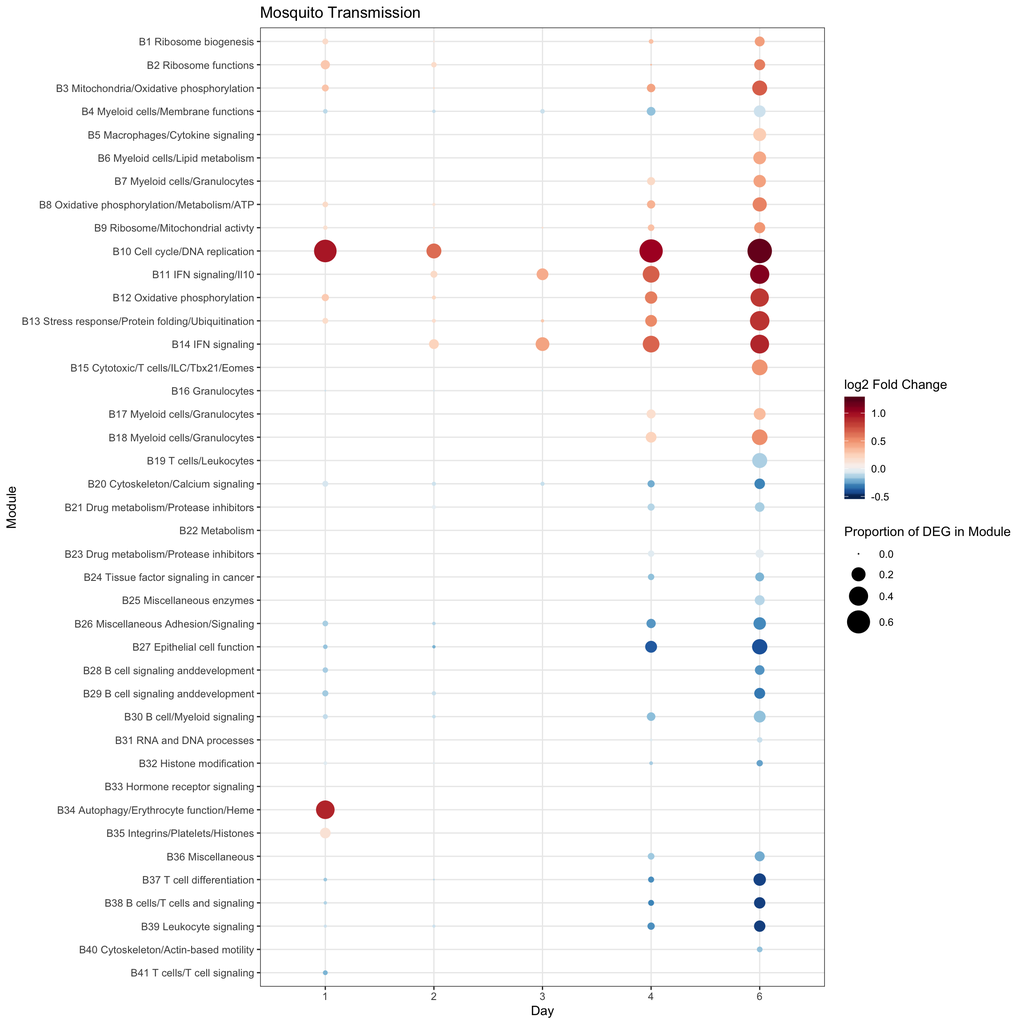

```r
mvn.cols <- grepl(pattern = "naive|^mt", x= names(count.mat));
mvn.mat <- count.mat[, mvn.cols];

if(!exists("results.mvn")){
  results.mvn <- lapply(c(1,2,3,4,6), function(d){
    cols <- grepl(pattern = paste("d", d ,"|naive", sep=""), x = names(mvn.mat))
    dat <- mvn.mat[, cols]
    print(names(dat))
    labels <- sapply(names(dat), function(x){
      ifelse(grepl(pattern = "mt", x = x), "mt","naive")
    })
    contrast = "mt-naive";
    qusage(dat, labels, contrast, module.geneset, n.points = 2^16)
  })
  names(results.mvn) <- c("Day1", "Day2", "Day3", "Day4", "Day6")
}

qusage.mvn <- lapply(names(results.mvn), function(x){
  df <- qsTable(results.mvn[[x]], number = 41)
  df$log.fold.change <- ifelse(df$p.Value < 0.05, df$log.fold.change, NA)
  df <- df[ ,c(1,2)]
  colnames(df) <- c("Module", paste(x, "_FC", sep = ""))
  df
})

qusage.mvn.all <- Reduce(function(x,y) merge(x = x, y = y, by = "Module", no.dups=T),
       qusage.mvn)
qusage.mvn.all <- qusage.mvn.all[match(names(module.geneset), qusage.mvn.all$Module), ]
qusage.mvn.all$Module <- factor(qusage.mvn.all$Module, levels = qusage.mvn.all$Module)

qusage.mvn.melt <- melt(qusage.mvn.all, id.vars = "Module")
qusage.mvn.melt$prop <-apply(qusage.mvn.melt, 1, function(prop){
  if (!is.na(prop[["value"]])){
  mod <- prop[[1]]
  day <- as.numeric(str_match(string = prop[2], pattern = "[0-9]"))
  geneset <- module.geneset[[mod]]
  num.genes <- length(geneset)
  deg.name <- grep(pattern = paste('^mt\\.', day, '_vs_naive', sep='')  , x = names(deg.list), value = TRUE);
  deg <- deg.list[[deg.name]]
  deg <- deg[geneset, ] %>% drop_na()
  output <- nrow(deg) / num.genes} else {output <- NA}
  output
})

x <- ggplot(qusage.mvn.melt, aes(x = variable, y = reorder(Module, desc(Module)))) +
  ggtitle('Mosquito Transmission') + xlab('Day') + ylab('Module') +
  scale_x_discrete(labels= c(1,2,3,4,6)) +
  geom_count(aes(size = prop, colour = value), na.rm = TRUE) +
  labs(size = "Proportion of DEG in Module", colour = 'log2 Fold Change') +
  scale_color_gradientn(colours = rev(brewer.pal(11, "RdBu")),values = rescale(c(-0.5,0,1.25)), limits = c(-0.5,1.25)) +
  scale_size_area(max_size = 9) +
  theme_bw() +
  theme(panel.grid.minor = element_blank(),
  panel.background = element_rect(fill = 'white'),
  plot.background = element_blank(),
  legend.background = element_rect(fill = 'transparent'))

x
```

### SBP vs Naive

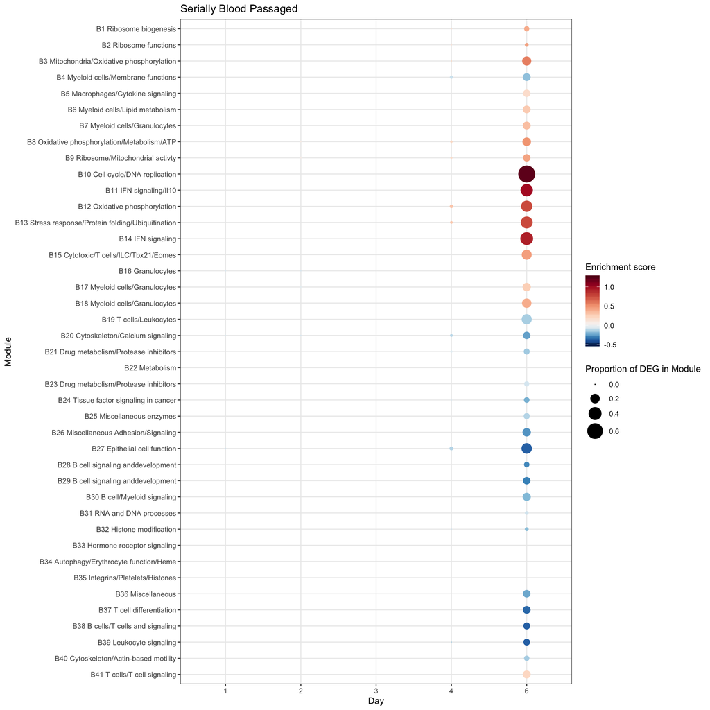

```r
svn.cols <- grepl(pattern = "naive|^sbp", x= names(count.mat));
svn.mat <- count.mat[, svn.cols];

if(!exists("results.svn")){
  results.svn <- lapply(c(1,2,3,4,6), function(d){
    cols <- grepl(pattern = paste("d", d ,"|naive", sep=""), x = names(svn.mat));
    dat <- svn.mat[, cols]
    print(names(dat))
    labels <- sapply(names(dat), function(x){
      ifelse(grepl(pattern = "sbp", x = x), "sbp","naive")
    })
    contrast = "sbp-naive";
    qusage(dat, labels, contrast, module.geneset, n.points = 2^16);
  })
  names(results.svn) <- c("Day1", "Day2", "Day3", "Day4", "Day6")
}

qusage.svn <- lapply(names(results.svn), function(x){
  df <- qsTable(results.svn[[x]], number = 41)
  df$log.fold.change <- ifelse(df$p.Value < 0.05, df$log.fold.change, NA)
  df <- df[ ,c(1,2)]
  colnames(df) <- c("Module", paste(x, "_FC", sep = ""))
  df
})

qusage.svn.all <- Reduce(function(x,y) merge(x = x, y = y, by = "Module", no.dups=T),
       qusage.svn)
qusage.svn.all <- qusage.svn.all[match(names(module.geneset), qusage.svn.all$Module), ]
qusage.svn.all$Module <- factor(qusage.svn.all$Module, levels = qusage.svn.all$Module)

qusage.svn.melt <- melt(qusage.svn.all, id.vars = "Module")
qusage.svn.melt$prop <-apply(qusage.svn.melt, 1, function(prop){
  if (!is.na(prop[["value"]])){
  mod <- prop[[1]]
  day <- as.numeric(str_match(string = prop[2], pattern = "[0-9]"))
  geneset <- module.geneset[[mod]]
  num.genes <- length(geneset)
  deg.name <- grep(pattern = paste('^sbp\\.', day, '_vs_naive', sep='')  , x = names(deg.list), value = TRUE);
  deg <- deg.list[[deg.name]]
  deg <- deg[geneset, ] %>% drop_na()
  output <- nrow(deg) / num.genes} else {output <- NA}
  output
})

x <- ggplot(qusage.svn.melt, aes(x = variable, y = reorder(Module, desc(Module)))) +
  ggtitle('Serially Blood Passaged') + xlab('Day') + ylab('Module') +
  scale_x_discrete(labels= c(1,2,3,4,6)) +
  geom_count(aes(size = prop, colour = value), na.rm = TRUE) +
  labs(size = "Proportion of DEG in Module", colour = 'Enrichment score') +
  scale_color_gradientn(colours = rev(brewer.pal(11, "RdBu")),values = rescale(c(-0.5,0,1.25)), limits = c(-0.5,1.25)) +
  scale_size_area(max_size = 9) +
  theme_bw() +
  theme(panel.grid.minor = element_blank(),
  panel.background = element_rect(fill = 'white'),
  plot.background = element_blank(),
  legend.background = element_rect(fill = 'transparent'))

x
```

### RTMT vs Naive

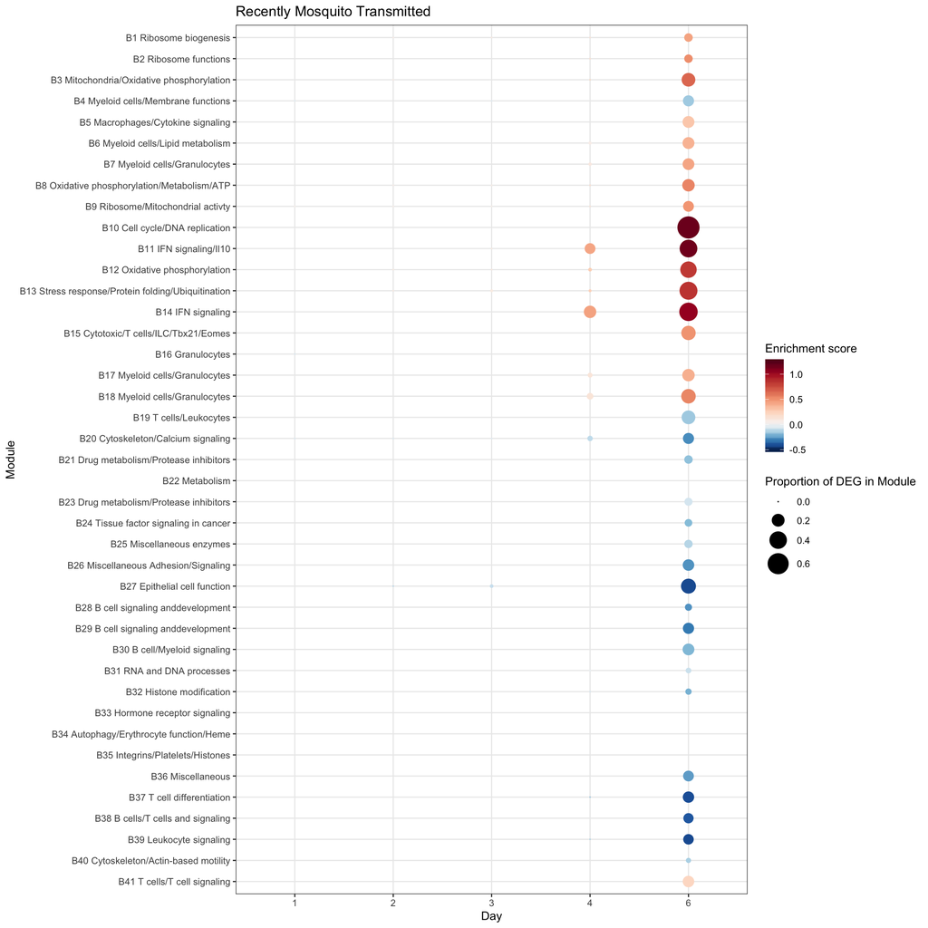

```r
rvn.cols <- grepl(pattern = "naive|^rtmt", x= names(count.mat));
rvn.mat <- count.mat[, rvn.cols];

if(!exists("results.rvn")){
  results.rvn <- lapply(c(1,2,3,4,6), function(d){
    cols <- grepl(pattern = paste("d", d ,"|naive", sep=""), x = names(rvn.mat));
    dat <- rvn.mat[, cols]
    print(names(dat))
    labels <- sapply(names(dat), function(x){
      ifelse(grepl(pattern = "rtmt", x = x), "rtmt","naive")
    })
    print(labels)
    contrast = "rtmt-naive";
    qusage(dat, labels, contrast, module.geneset, n.points = 2^16);
  })
  names(results.rvn) <- c("Day1", "Day2", "Day3", "Day4", "Day6")
}

qusage.rvn <- lapply(names(results.rvn), function(x){
  df <- qsTable(results.rvn[[x]], number = 41)
  df$log.fold.change <- ifelse(df$p.Value < 0.05, df$log.fold.change, NA)
  df <- df[ ,c(1,2)]
  colnames(df) <- c("Module", paste(x, "_FC", sep = ""))
  df
})

qusage.rvn.all <- Reduce(function(x,y) merge(x = x, y = y, by = "Module", no.dups=T),
       qusage.rvn)
qusage.rvn.all <- qusage.rvn.all[match(names(module.geneset), qusage.rvn.all$Module), ]
qusage.rvn.all$Module <- factor(qusage.rvn.all$Module, levels = qusage.rvn.all$Module)

qusage.rvn.melt <- melt(qusage.rvn.all, id.vars = "Module")
qusage.rvn.melt$prop <-apply(qusage.rvn.melt, 1, function(prop){
  if (!is.na(prop[["value"]])){
  mod <- prop[[1]]
  day <- as.numeric(str_match(string = prop[2], pattern = "[0-9]"))
  geneset <- module.geneset[[mod]]
  num.genes <- length(geneset)
  deg.name <- grep(pattern = paste('^rtmt\\.', day, '_vs_naive', sep='')  , x = names(deg.list), value = TRUE);
  deg <- deg.list[[deg.name]]
  deg <- deg[geneset, ] %>% drop_na()
  output <- nrow(deg) / num.genes} else {output <- NA}
  output
})

x <- ggplot(qusage.rvn.melt, aes(x = variable, y = reorder(Module, desc(Module)))) +
  ggtitle('Recently Mosquito Transmitted') + xlab('Day') + ylab('Module') +
  scale_x_discrete(labels= c(1,2,3,4,6)) +
  geom_count(aes(size = prop, colour = value), na.rm = TRUE) +
  labs(size = "Proportion of DEG in Module", colour = 'Enrichment score') +
  scale_color_gradientn(colours = rev(brewer.pal(11, "RdBu")),values = rescale(c(-0.5,0,1.25)), limits = c(-0.5,1.25)) +
  scale_size_area(max_size = 9) +
  theme_bw() +
  theme(panel.grid.minor = element_blank(),
  panel.background = element_rect(fill = 'white'),
  plot.background = element_blank(),
  legend.background = element_rect(fill = 'transparent'))

x
```

```r
if(!file.exists(paste(r.dir, "Projects/qusage_results.Rdata", sep = ""))){
save(results.mvn, results.svn, results.rvn, file = paste(r.dir, "Projects/qusage_results.Rdata", sep = ""))
}
```